# Acceleration of Metropolis-Hasting Algorithm

Tairan

April 26, 2018

## Motivation

Compared to the Gibbs sampling and Slice sampling, the Metropolis-Hasting algorithm might be the most inefficient one.

- Unable to update the sample at every iteration: the optimal acceptance rate is 20%~30%
- Significant computation efficiency bottleneck

However, in some situations, we have to employ Metropolis-Hasting:

- The posterior distribution is not in a closed form
- The shape of sample distribution might be multi-modals

## Solution from C++

- C++ is a general-purpose programming language, which also provides facilities for low-level memory manipulation.
- The ideal procedure to analyze the posterior distribution is to generate the sampling distribution in C++ and then study its properties in R with a mass of available packages.
- The RCpp package provides R functions as well as C++ classes which offer a seamless integration of R and C++. Many R data types and objects can be mapped back and forth to C++ equivalents which facilitates both writing of new code as well as easier integration of third-party libraries.

## Key Packages in RCpp

### Rcpp

- Rcpp provides a powerful API on top of R, permitting direct interchange of rich R objects between R and C++
- Rcpp sugar gives syntactic sugar such as vectorised C++ expression
- Rcpp modules provide easy extensibility using declarations and Rcpp attributes greatly facilitates code integration.

### RcppArmadillo

- Rcpp connects R with the powerful Armadillo templated C++ library for linear algebra
- Armadillo aims towards a good balance between speed and ease of use, and its syntax is deliberately similar to Matlab which makes it easy to port existing code

[Armadillo help document](http://arma.sourceforge.net/docs.html)

### RcppEigen

- RcppEigen gives R access to the high-performance Eigen linear algebra library.

### RInside

- The RInside package provides C++ classes that make it easier to embed R in C++ code

## Model

### Data:

- $Y$, the binary outcome, indicates the occurrence of accident in a specified time period
- $X_1$, the binary variable, records if the driver is charged of a moving violation
- $X_2$ and $X_3$ are two dummies variables for driving history, which is categorical with 3 levels.

$$X_2 = 0 \text{ & } X_3 = 0 \text{ if age } \in (0, 5]$$
$$X_2 = 1 \text{ & } X_3 = 0 \text{ if age } \in (5, 15)$$
$$X_2 = 0 \text{ & } X_3 = 1 \text{ if age } \in (15, \infty)$$

- The sample size $n$ is 50

### Model with a Bayesian logistic regression:

$$logit(Y)=\beta_0 + \beta_1 X_1 + \beta_2 X_2 + \beta_3 X_3$$

### The noninformative prior for $\vec{\beta}$:

$$\beta_0, \beta_1, \beta_2, \beta_3 \sim N(0, 10^2)$$

### The posterior distribution can be easily achieved:

- Obviously no conjugacy and even closed form here – Metropolis-Hasting is employed

## Sampling

### The sampling procedure:

- Sample the proposal distribution, which is centered and symmetric around $\beta^{(s)}$
  $$\beta^* \sim N(\beta^{(s)}, \sigma_p^2)$$
- Compute the acceptance ratio:

$$r=\frac{ f({ \beta^* }|X, Y)}{ f({ \beta^{(s)} }|X, Y)} *
\frac{ N(\beta^{(s)}|\beta^*) }{ N(\beta^*|\beta^{(s)})}$$

- Update the sequence
  $$\beta^{(s+1)}=\beta^* \text{ if } r>u \sim U(0,1)$$
  $$\beta^{(s+1)}=\beta^{(s)} \text{ if } r<u \sim U(0,1)$$

### Algorithm:

- set a starting point to $\beta$
- build a *for* loop to sequentially update $\beta$ with above sampling procedure
- manipulate the MCMC chain – burn-in, gap, and relative test

### Three approach:

- Complete all the sampling in R

```r
# compute the log posterior of beta vector
log_posterior<-function(beta, X, Y){

  # calculate likelihood
  p_i <- invlogit(X %*% beta)
  likelihood <- sum(dbern(Y, p_i, log = T))

  # calculate prior
  prior <- dmvn(x = beta, mu = rep(0,p), Sigma = sqrt((10^2)*diag(p)), log = T)

  # calculate the posterior
  log_post <- likelihood + prior

  return(log_post)
}
```

```r
# Generate the sample distribution

for(i in 2:iteration){
  beta_s <- BETA[i-1, ]

  # sample from proposal distribution
  beta_star <- mvrnorm(n = 1, beta_s, Sigma = sqrt(jump_v*diag(p)))

  # calculate acceptance probability
  r_num <- log_posterior(beta_star, X, Y ) +
            dmvnorm(x = beta_s, mean = beta_star, sigma = sqrt(jump_v*diag(p)))
  r_denom <- log_posterior(beta_s, X, Y ) +
            dmvnorm(x = beta_star, mean = beta_s, sigma = sqrt(jump_v*diag(p)))

  r <- r_num - r_denom
  rmin<-min(r,log(1))

  # accept or reject proposal
  if( rmin > log(runif(n = 1, min = 0, max = 1)) ){
    BETA[i, ] <- beta_star
  }else{
    BETA[i, ] <- beta_s
  }
  accept[i] <- rmin
}
```

- Compute the likelihood in C++ and conduct the update procedure, *for* loop, in R

```cpp
// [[Rcpp::depends(RcppArmadillo)]]
#include <RcppArmadillo.h>
#include <Rcpp.h>
#include <math.h>
using namespace Rcpp;
using namespace arma;

// [[Rcpp::export]]
double log_post(vec b, vec Y, mat X, vec b_s, double jump_v) {
  int n = X.n_rows;
  int p = X.n_cols;
  vec xb;
  vec pi;
  double likelihood;
  double prior;
  double proposal;
  double log_posterior;

  // linear predictor
  xb =  X*b;
  pi = invlogit(xb);

  // compute log likelihood
  likelihood = 0;
  for(int i=0; i<n; i++){
    likelihood = likelihood + R::dbinom(Y[i], 1, pi[i], 1);
  }

  // compute log prior
  prior=0;
  for(int i=0; i<p; i++){
    prior = prior + R::dnorm4(b[i], 0, 10, 1);
  }

  // compute the proposal density
  sd = diagmat(sqrt(jump_v) * ones<vec>(p));
  proposal = normpdf(b_s, b, sd);

  // evaluate log posterior as sum of likelihood and prior
  log_posterior = likelihood + prior + proposal;
  return log_posterior;
}
```

- Complete all the sampling in C++

```cpp
// [[Rcpp::export]]
List for_log_post(mat X, vec Y, int iter, double jump_v){

    int p = X.n_cols;
    mat beta_shell(iter, p);
    vec accept_result(iter);

    // starting value
    beta_result.row(0) = ones<vec>(p).t();
    vec beta_0(p);
    mat sd(p, p);
    vec beta_star(p);

    double r_denum = 0;
    double r_num = 0;
    double r = 0;
    double rmin = 0;
    double uni = 0;

    for(int i = 1; i < iter; i++){
        beta_0 = trans(beta_result.row(i-1));
        sd = diagmat(sqrt(jump_v) * ones<vec>(p));

        // sample from proposal distribution
        beta_star = mvnrnd(beta_0, sd);
        // ratio computation
        r_num = log_post(beta_star, Y, X, beta_0);
        r_denum = log_post(beta_0, Y, X, beta_Star);
        // acceptance ratio
        r = exp(r_num - r_denum);
        rmin = fmin(r, 1);

        //decision
        uni = randu<double>();
        if (rmin > uni){
            beta_result.row(i) = beta_star.t();
        } else {
            beta_result.row(i) = beta_0.t();
        }
        accept_result(i) = rmin;
    }
    List result;
    result["beta_result"] = beta_result;
    result["accept_result"] = accept_result;
    return result;
}
```

## Result

### Traceplots:

- Pure R

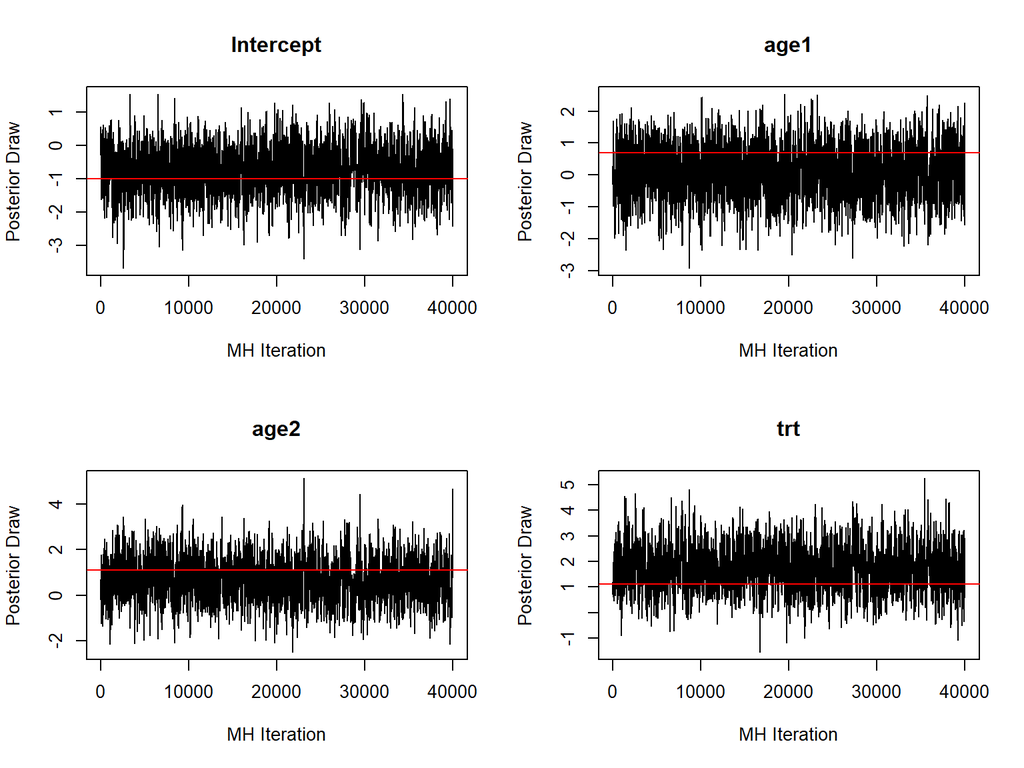

- Only computation of likelihood in C++

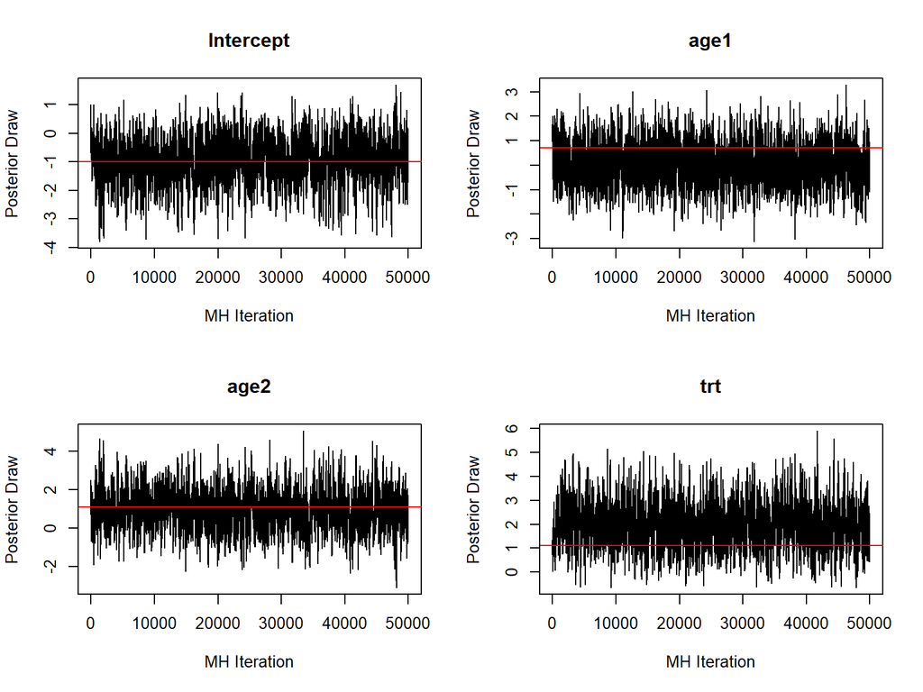

- Pure C++

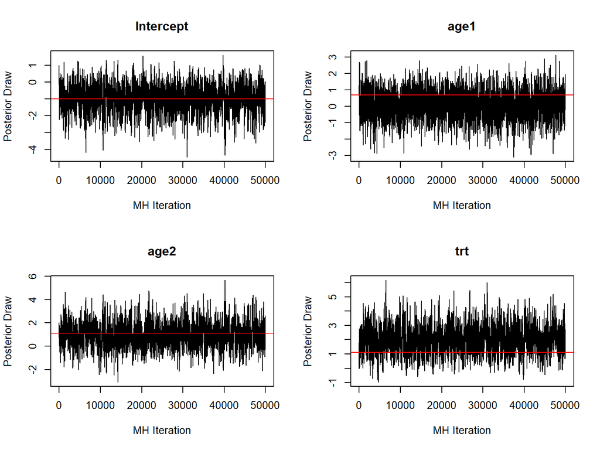

### Running Time:

The R function *microbenchmark* is used here to measure the running time accurately, which is a good substitution for the *system.time(replicate(repeat_time, function))* expression. The result is as following:

```
## Unit: milliseconds
##                                                      expr       min
##             sample_mh(X, Y, iter = iter, jump_v = jump_v) 9414.6885
##         sample_mh_cpp(X, Y, iter = iter, jump_v = jump_v) 1357.1020
##  for_log_post(X = X, Y = Y, iter = iter, jump_v = jump_v)  208.6361
##          lq       mean     median         uq        max neval
##  10161.0829 10817.4321 10695.8204 11385.2395 13682.3610   100
##   1467.1162  1604.7589  1540.1386  1719.9032  2200.7322   100
##    225.4888   267.1713   251.2467   287.7222   556.7897   100
```

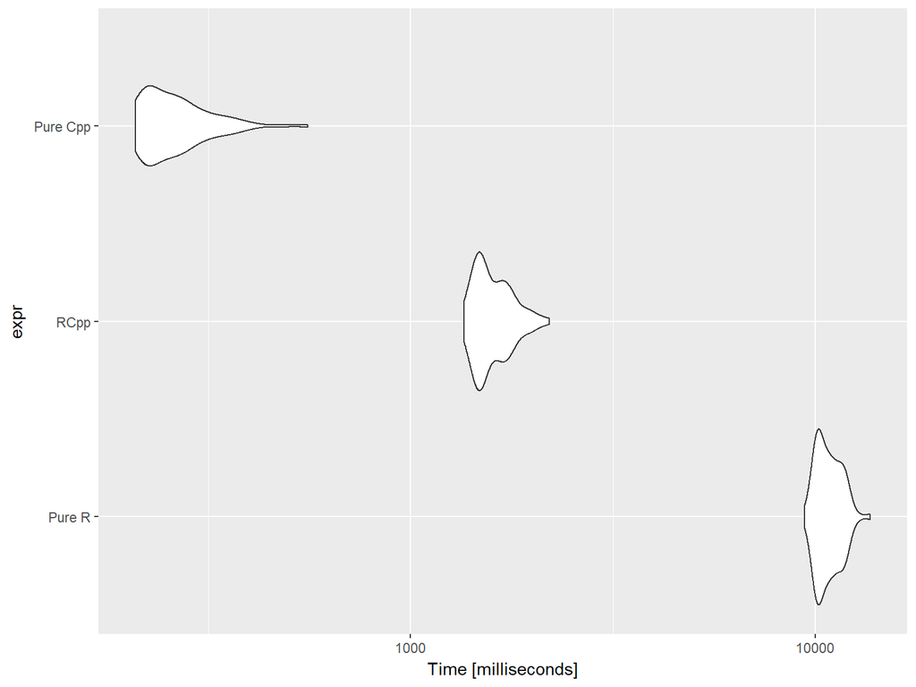

## Running Time against Sample Size

In previous case, we study the case with sample size 50. The table and plot below presents the relative running time with pure R method as baseline, against the sample size of 50 to 500 in increment of 50.

```
##    Sample Size   Rcpp/R     Cpp/R
## 1           50 6.395804 44.165878
## 2          100 5.733917 23.396982
## 3          150 5.226199 16.266281
## 4          200 4.865500 12.384171
## 5          250 4.517597  9.987782
## 6          300 4.226223  8.626818
## 7          350 4.077160  7.691844
## 8          400 3.818126  6.797636
## 9          450 3.702884  6.334083
## 10         500 3.545011  5.751574
```

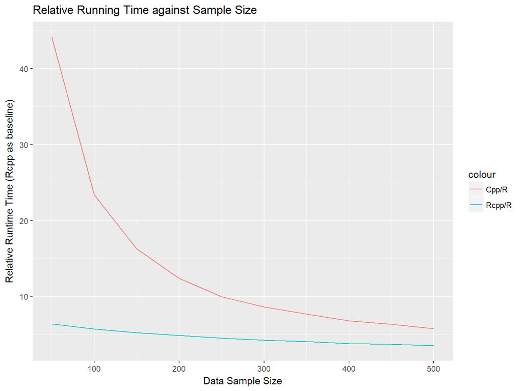